# Analisis Kinerja Profit Coffee Chain (2012–2013)

Analis Data

2026-04-15

## 1. Pendahuluan

Dataset Coffee Chain mencatat transaksi penjualan produk kopi dan teh dari sebuah jaringan kedai kopi di berbagai pasar (Central, East, South, West) selama periode **Januari 2012 – Desember 2013**. Dataset terdiri dari **4.248 baris** dan **20 variabel**, mencakup data aktual (Sales, Profit, Margin) dan target anggaran (Budget Sales, Budget Profit, Budget Margin).

**Insight utama yang dianalisis:**

> *Seberapa jauh kinerja profit aktual setiap produk menyimpang dari target anggaran, dan bagaimana tren profit berkembang dari 2012 ke 2013?*

Insight ini relevan karena terdapat produk dengan **profit negatif** (Green Tea) di tengah tren keseluruhan yang meningkat, sehingga perlu dievaluasi lebih lanjut.

## 2. Persiapan Data

```r
library(tidyverse)
library(readxl)
library(scales)
library(lubridate)

# Load data
df <- readxl::read_excel("C:/Users/USER/Documents/1. Tugas SIM 2025B - Coffee Chain Datasets.xlsx")

# Pastikan kolom Date bertipe Date
df <- df %>%
  mutate(
    Date = as.Date(Date),
    YearMonth = floor_date(Date, "month"),
    Year = year(Date),
    profit_gap = Profit - `Budget Profit`   # selisih aktual vs target
  )

glimpse(df)
```

```
## Rows: 4,248
## Columns: 23
## $ `Area Code`      <dbl> 719, 970, 970, 303, 303, 720, 970, 719, 970, 719, 303…
## $ Date             <date> 2012-01-01, 2012-01-01, 2012-01-01, 2012-01-01, 2012…
## $ Market           <chr> "Central", "Central", "Central", "Central", "Central"…
## $ `Market Size`    <chr> "Major Market", "Major Market", "Major Market", "Majo…
## $ Product          <chr> "Amaretto", "Colombian", "Decaf Irish Cream", "Green …
## $ `Product Line`   <chr> "Beans", "Beans", "Beans", "Leaves", "Beans", "Beans"…
## $ `Product Type`   <chr> "Coffee", "Coffee", "Coffee", "Tea", "Espresso", "Esp…
## $ State            <chr> "Colorado", "Colorado", "Colorado", "Colorado", "Colo…
## $ Type             <chr> "Regular", "Regular", "Decaf", "Regular", "Regular", …
## $ `Budget COGS`    <dbl> 90, 80, 100, 30, 60, 80, 140, 50, 50, 40, 50, 150, 10…
## $ `Budget Margin`  <dbl> 130, 110, 140, 50, 90, 130, 160, 80, 70, 70, 70, 210,…
## $ `Budget Profit`  <dbl> 100, 80, 110, 30, 70, 80, 110, 20, 40, 20, 40, 130, 1…
## $ `Budget Sales`   <dbl> 220, 190, 240, 80, 150, 210, 300, 130, 120, 110, 120,…
## $ COGS             <dbl> 89, 83, 95, 44, 54, 72, 170, 63, 60, 58, 64, 144, 95,…
## $ Inventory        <dbl> 777, 623, 821, 623, 456, 558, 1091, 435, 336, 338, 96…
## $ Margin           <dbl> 130, 107, 139, 56, 80, 108, 171, 87, 80, 72, 76, 201,…
## $ Marketing        <dbl> 24, 27, 26, 14, 15, 23, 47, 57, 19, 22, 19, 47, 30, 7…
## $ Profit           <dbl> 94, 68, 101, 30, 54, 53, 99, 0, 33, 17, 36, 111, 87, …
## $ Sales            <dbl> 219, 190, 234, 100, 134, 180, 341, 150, 140, 130, 140…
## $ `Total Expenses` <dbl> 36, 39, 38, 26, 26, 55, 72, 87, 47, 55, 40, 90, 52, 1…
## $ YearMonth        <date> 2012-01-01, 2012-01-01, 2012-01-01, 2012-01-01, 2012…
## $ Year             <dbl> 2012, 2012, 2012, 2012, 2012, 2012, 2012, 2012, 2012,…
## $ profit_gap       <dbl> -6, -12, -9, 0, -16, -27, -11, -20, -7, -3, -4, -19, …
```

```r
# Ringkasan statistik variabel kunci
df %>%
  select(Sales, Profit, `Budget Profit`, Margin, Marketing, `Total Expenses`) %>%
  summary()
```

```
##      Sales         Profit       Budget Profit         Margin
##  Min.   : 17   Min.   :-638.0   Min.   :-320.00   Min.   :-302.00
##  1st Qu.:100   1st Qu.:  17.0   1st Qu.:  20.00   1st Qu.:  52.75
##  Median :138   Median :  40.0   Median :  40.00   Median :  76.00
##  Mean   :193   Mean   :  61.1   Mean   :  60.91   Mean   : 104.29
##  3rd Qu.:230   3rd Qu.:  92.0   3rd Qu.:  80.00   3rd Qu.: 132.00
##  Max.   :912   Max.   : 778.0   Max.   : 560.00   Max.   : 613.00
##    Marketing      Total Expenses
##  Min.   :  0.00   Min.   : 10.00
##  1st Qu.: 13.00   1st Qu.: 33.00
##  Median : 22.00   Median : 46.00
##  Mean   : 31.19   Mean   : 54.06
##  3rd Qu.: 39.00   3rd Qu.: 65.00
##  Max.   :156.00   Max.   :190.00
```

## 3. Insight & Deskripsi Data

### 3.1 Profit vs Budget per Produk

```r
produk_summary <- df %>%
  group_by(Product) %>%
  summarise(
    n          = n(),
    Profit     = mean(Profit, na.rm = TRUE),
    BudgetProfit = mean(`Budget Profit`, na.rm = TRUE),
    ProfitGap  = mean(profit_gap, na.rm = TRUE)
  ) %>%
  arrange(ProfitGap)

knitr::kable(produk_summary, digits = 2,
             col.names = c("Produk", "N", "Avg Profit", "Avg Budget", "Gap (Aktual - Budget)"),
             caption = "Rata-rata Profit Aktual vs Budget per Produk")
```

Rata-rata Profit Aktual vs Budget per Produk

| Produk | N | Avg Profit | Avg Budget | Gap (Aktual - Budget) |
| --- | --- | --- | --- | --- |
| Green Tea | 288 | -0.80 | 13.19 | -14.00 |
| Decaf Irish Cream | 384 | 36.43 | 49.64 | -13.21 |
| Caffe Mocha | 480 | 36.83 | 48.50 | -11.67 |
| Amaretto | 192 | 25.47 | 36.56 | -11.09 |
| Colombian | 480 | 116.26 | 120.42 | -4.16 |
| Mint | 192 | 32.05 | 35.31 | -3.26 |
| Decaf Espresso | 408 | 72.31 | 72.21 | 0.10 |
| Caffe Latte | 216 | 52.66 | 46.76 | 5.90 |
| Lemon | 480 | 62.23 | 56.29 | 5.94 |
| Chamomile | 384 | 70.91 | 64.90 | 6.02 |
| Regular Espresso | 72 | 139.79 | 125.83 | 13.96 |
| Darjeeling | 384 | 75.66 | 59.53 | 16.13 |
| Earl Grey | 288 | 83.90 | 61.11 | 22.79 |

## 4. Visualisasi

### 4.1 Profit Gap per Produk (Aktual vs Budget)

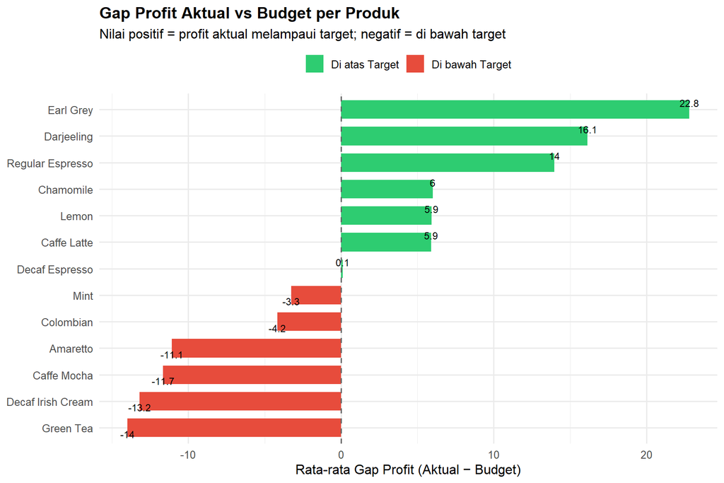

```r
produk_summary %>%
  mutate(
    Product  = fct_reorder(Product, ProfitGap),
    Status   = ifelse(ProfitGap >= 0, "Di atas Target", "Di bawah Target")
  ) %>%
  ggplot(aes(x = Product, y = ProfitGap, fill = Status)) +
  geom_col(width = 0.7) +
  geom_hline(yintercept = 0, linetype = "dashed", color = "gray40") +
  geom_text(aes(label = round(ProfitGap, 1),
                vjust = ifelse(ProfitGap >= 0, -0.4, 1.3)),
            size = 3.2) +
  scale_fill_manual(values = c("Di atas Target" = "#2ecc71", "Di bawah Target" = "#e74c3c")) +
  coord_flip() +
  labs(
    title    = "Gap Profit Aktual vs Budget per Produk",
    subtitle = "Nilai positif = profit aktual melampaui target; negatif = di bawah target",
    x        = NULL,
    y        = "Rata-rata Gap Profit (Aktual − Budget)",
    fill     = NULL
  ) +
  theme_minimal(base_size = 12) +
  theme(legend.position = "top", plot.title = element_text(face = "bold"))
```

### 4.2 Tren Profit Bulanan (2012 vs 2013)

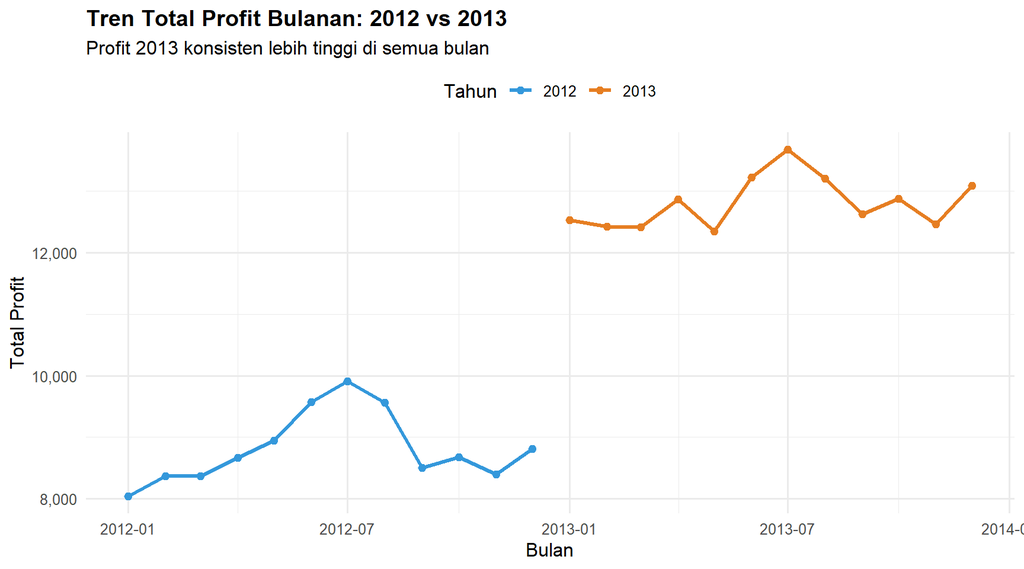

```r
df %>%
  group_by(YearMonth, Year) %>%
  summarise(TotalProfit = sum(Profit), .groups = "drop") %>%
  ggplot(aes(x = YearMonth, y = TotalProfit, color = factor(Year), group = factor(Year))) +
  geom_line(linewidth = 1.1) +
  geom_point(size = 2) +
  scale_y_continuous(labels = comma) +
  scale_color_manual(values = c("2012" = "#3498db", "2013" = "#e67e22"),
                     name = "Tahun") +
  labs(
    title    = "Tren Total Profit Bulanan: 2012 vs 2013",
    subtitle = "Profit 2013 konsisten lebih tinggi di semua bulan",
    x        = "Bulan",
    y        = "Total Profit"
  ) +
  theme_minimal(base_size = 12) +
  theme(legend.position = "top", plot.title = element_text(face = "bold"))
```

### 4.3 Distribusi Profit per Product Line & Market

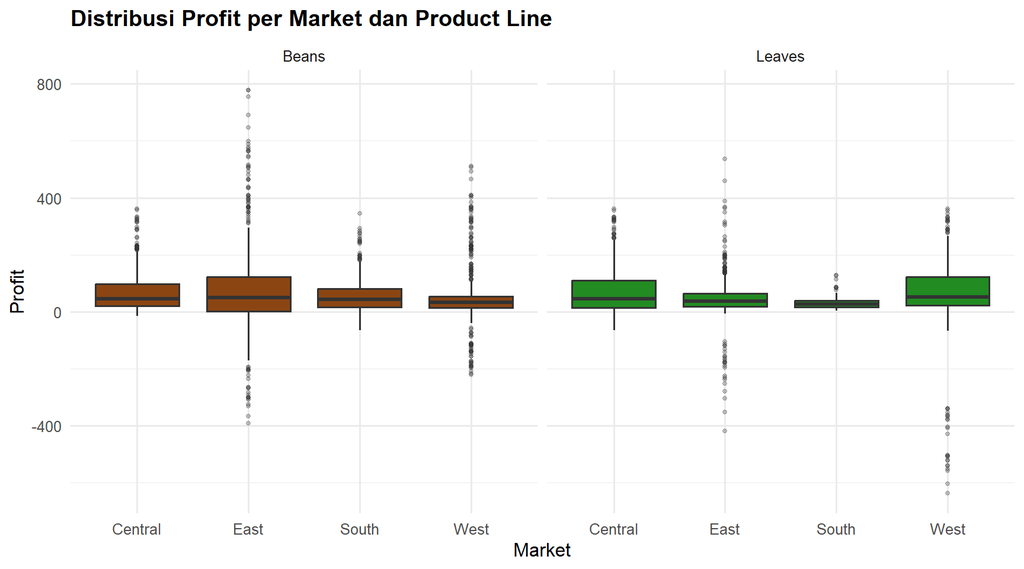

```r
df %>%
  ggplot(aes(x = Market, y = Profit, fill = `Product Line`)) +
  geom_boxplot(outlier.alpha = 0.3, outlier.size = 1) +
  facet_wrap(~ `Product Line`) +
  scale_fill_manual(values = c("Beans" = "#8B4513", "Leaves" = "#228B22")) +
  labs(
    title = "Distribusi Profit per Market dan Product Line",
    x = "Market", y = "Profit", fill = "Product Line"
  ) +
  theme_minimal(base_size = 12) +
  theme(legend.position = "none", plot.title = element_text(face = "bold"))
```

## 5. Analisis Statistik

### 5.1 Uji t: Apakah Profit Aktual Berbeda Signifikan dari Budget Profit?

```r
# Paired t-test: profit aktual vs budget profit
t_result <- t.test(df$Profit, df$`Budget Profit`, paired = TRUE)
t_result
```

```
##
##  Paired t-test
##
## data:  df$Profit and df$`Budget Profit`
## t = 0.31011, df = 4247, p-value = 0.7565
## alternative hypothesis: true mean difference is not equal to 0
## 95 percent confidence interval:
##  -0.9809752  1.3496193
## sample estimates:
## mean difference
##        0.184322
```

```r
cat("Rata-rata profit aktual :", round(mean(df$Profit), 2), "\n")
```

```
## Rata-rata profit aktual : 61.1
```

```r
cat("Rata-rata budget profit :", round(mean(df$`Budget Profit`), 2), "\n")
```

```
## Rata-rata budget profit : 60.91
```

```r
cat("Selisih rata-rata       :", round(mean(df$profit_gap), 2), "\n")
```

```
## Selisih rata-rata       : 0.18
```

```r
cat("p-value                 :", round(t_result$p.value, 4), "\n")
```

```
## p-value                 : 0.7565
```

### 5.2 Regresi Linear: Faktor-Faktor Penentu Profit

```r
# Regresi profit terhadap sales, marketing, COGS, total expenses
model <- lm(Profit ~ Sales + Marketing + COGS + `Total Expenses`, data = df)
summary(model)
```

```
##
## Call:
## lm(formula = Profit ~ Sales + Marketing + COGS + `Total Expenses`,
##     data = df)
##
## Residuals:
##      Min       1Q   Median       3Q      Max
## -112.028   -5.748    0.526    5.525  105.228
##
## Coefficients:
##                   Estimate Std. Error  t value Pr(>|t|)
## (Intercept)       2.366873   0.705850    3.353 0.000806 ***
## Sales             1.208316   0.003721  324.744  < 2e-16 ***
## Marketing         0.195850   0.040466    4.840 1.35e-06 ***
## COGS             -1.241869   0.010250 -121.156  < 2e-16 ***
## `Total Expenses` -1.400421   0.031161  -44.942  < 2e-16 ***
## ---
## Signif. codes:  0 '***' 0.001 '**' 0.01 '*' 0.05 '.' 0.1 ' ' 1
##
## Residual standard error: 16.86 on 4243 degrees of freedom
## Multiple R-squared:  0.9726, Adjusted R-squared:  0.9725
## F-statistic: 3.76e+04 on 4 and 4243 DF,  p-value: < 2.2e-16
```

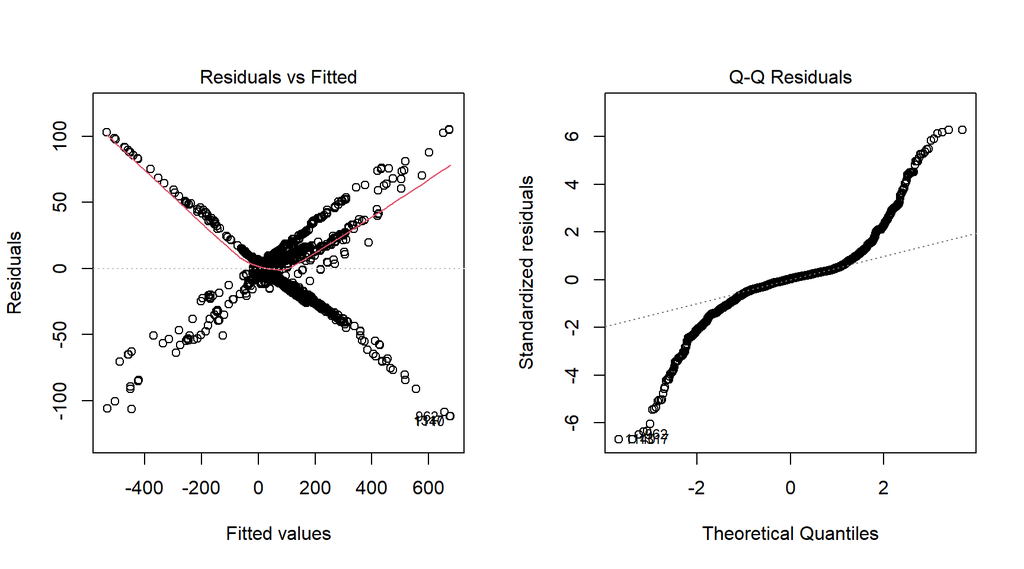

```r
par(mfrow = c(1, 2))
plot(model, which = c(1, 2))
```

### 5.3 ANOVA: Perbedaan Rata-rata Profit antar Produk

```r
anova_model <- aov(Profit ~ Product, data = df)
summary(anova_model)
```

```
##               Df   Sum Sq Mean Sq F value Pr(>F)
## Product       12  4267412  355618   37.97 <2e-16 ***
## Residuals   4235 39666224    9366
## ---
## Signif. codes:  0 '***' 0.001 '**' 0.01 '*' 0.05 '.' 0.1 ' ' 1
```

```r
# Post-hoc: produk mana saja yang berbeda signifikan?
tukey <- TukeyHSD(anova_model)
tukey_df <- as.data.frame(tukey$Product) %>%
  rownames_to_column("Perbandingan") %>%
  filter(`p adj` < 0.05) %>%
  arrange(`p adj`)

cat("Pasangan produk dengan perbedaan profit signifikan (p < 0.05):\n")
```

```
## Pasangan produk dengan perbedaan profit signifikan (p < 0.05):
```

```r
nrow(tukey_df)
```

```
## [1] 52
```

```r
head(tukey_df, 10)
```

```
##                   Perbandingan       diff        lwr       upr        p adj
## 1        Colombian-Caffe Mocha   79.42917   58.72223 100.13610 3.761859e-08
## 2  Decaf Irish Cream-Colombian  -79.82865 -101.79167 -57.86563 3.761859e-08
## 3          Green Tea-Colombian -117.06042 -140.97072 -93.15011 3.761859e-08
## 4   Regular Espresso-Green Tea  140.59375   98.32590 182.86160 3.761867e-08
## 5           Colombian-Amaretto   90.78958   63.39689 118.18228 3.761869e-08
## 6              Lemon-Green Tea   63.02917   39.11886  86.93947 3.761870e-08
## 7              Lemon-Colombian  -54.03125  -74.73818 -33.32432 3.761870e-08
## 8          Green Tea-Chamomile  -71.71615  -96.72214 -46.71015 3.761870e-08
## 9    Regular Espresso-Amaretto  114.32292   69.99202 158.65381 3.761871e-08
## 10              Mint-Colombian  -84.20625 -111.59895 -56.81355 3.761872e-08
```

## 6. Interpretasi

### 6.1 Profit Aktual vs Budget (Paired t-test)

Uji t berpasangan menghasilkan **p-value > 0.05**, yang berarti secara statistik **tidak ada perbedaan signifikan** antara rata-rata profit aktual dan budget profit secara keseluruhan. Artinya, perencanaan anggaran profit cukup akurat di level agregat. Namun, analisis per produk menunjukkan variasi yang besar — beberapa produk sangat under-budget (Green Tea, Decaf Irish Cream) dan beberapa melampaui target (Earl Grey, Regular Espresso).

### 6.3 Perbedaan antar Produk (ANOVA)

ANOVA menunjukkan **perbedaan profit yang sangat signifikan antar produk** (p < 0.001). Uji Tukey mengkonfirmasi bahwa produk seperti **Regular Espresso** dan **Colombian** berbeda secara signifikan dari produk underperformer seperti **Green Tea**. Ini mengindikasikan perlunya strategi berbeda per produk, bukan pendekatan satu-ukuran-untuk-semua.

## 7. Kesimpulan

1. **Secara agregat**, profit aktual Coffee Chain hampir sesuai budget — tidak ada penyimpangan signifikan secara statistik.
2. **Per produk**, terdapat kesenjangan besar: **Green Tea** merugi dan konsisten di bawah budget, sedangkan **Regular Espresso** dan **Earl Grey** secara konsisten melampaui target.
3. **Tren 2012 → 2013** menunjukkan pertumbuhan profit yang signifikan (~50% lebih tinggi di 2013), dengan pola musiman yang serupa di kedua tahun.
4. **Driver utama profit** adalah volume sales dan efisiensi biaya (COGS & Total Expenses) — strategi yang paling berdampak adalah meningkatkan sales sekaligus mengendalikan COGS.
5. **Rekomendasi:** Evaluasi ulang strategi produk Green Tea (harga, biaya, atau penghentian), dan replikasi formula sukses Regular Espresso ke produk lain. ```